# MasterControl QAL Performance — Exploratory Data Analysis

Author

Group 4

# 1 Introduction

MasterControl operates in a competitive B2B SaaS environment where sales performance depends on effectively identifying and prioritizing high-quality leads. This dataset contains Qualified Account Leads (QALs) generated between 2024 and early 2026 across two primary product families: Qx (Quality) and Mx (Manufacturing). Qx is a mature product with over two decades of market presence, while Mx is newer and currently underperforming relative to Qx. The objective of this exploratory data analysis (EDA) is to understand structural drivers of lead progression, identify which account and contact characteristics influence Mx performance, and inform both predictive modeling and go-to-market strategy.

## 1.1 Data Import & Initial Structure

```r
library(tidyverse)
library(janitor)
library(lubridate)
library(skimr)
library(naniar)

qal_raw <- read_csv("QAL Performance for MSBA.csv")

qal <- qal_raw |>
  clean_names()

glimpse(qal)
```

```
Rows: 16,815
Columns: 14
$ acct_primary_site_function   <chr> "Food and beverage", "Small-molecule API"…
$ acct_manufacturing_model     <chr> "Consumer Packaged Goods", "In-House", "I…
$ acct_target_industry         <chr> "Non-Life Science", "Pharma & BioTech", "…
$ contact_lead_title           <chr> "QA Manager", "VP Quality&Regulatory Affa…
$ qal_id                       <chr> "a0dPQ000005WbfuYAC", "a0dPQ000008ye7dYAA…
$ contact_lead_id              <chr> "0030c00002XPeNGAA1", "0030c00002XR1uPAAT…
$ next_stage_c                 <chr> "SQL", "Recycled", "Recycled", "Recycled"…
$ priority                     <chr> "P1 - Webinar Demo", "No Priority", "Prio…
$ acct_territory_rollup        <chr> "Americas", "EMEA", "EMEA", "EMEA", "Amer…
$ acct_tier_rollup             <chr> "Medium", "Medium", "Small", "Small", "Sm…
$ solution                     <chr> "Mx", "Qx", "Qx", "Qx", "Mx", "Mx", "Qx",…
$ solution_rollup              <chr> "Mx", "Qx", "Qx", "Qx", "Mx", "Mx", "Qx",…
$ last_tactic_campaign_channel <chr> "Online Ads", "Outbound Prospecting", "Em…
$ qal_cohort_date              <date> 2025-06-16, 2025-09-19, 2024-02-22, 2025…
```

The dataset contains 16,815 rows and 14 columns. Each row represents one QAL, confirming a clean one-row-per-lead grain. Most variables are categorical, with one date field (qal_cohort_date). There are no obvious structural inconsistencies.

# 2 Target Variable Construction

```r
qal <- qal |>
  mutate(
    progressed = case_when(
      next_stage_c %in% c("SQL", "SQO", "Won") ~ 1,
      next_stage_c %in% c("Recycled", "Lost", "MQL", "INQ") ~ 0,
      TRUE ~ NA_real_
    )
  )

qal |> count(next_stage_c)
```

```
# A tibble: 9 × 2
  next_stage_c     n
  <chr>        <int>
1 Exclude       1227
2 INQ              2
3 Lost            12
4 MQL             10
5 Recycled     12067
6 SQL           2718
7 SQO            254
8 Won             42
9 <NA>           483
```

```r
qal_model <- qal |>
  filter(!next_stage_c %in% c("Exclude")) |>
  filter(!is.na(progressed))

qal_model |> count(progressed) |>
  mutate(pct = n / sum(n))
```

```
# A tibble: 2 × 3
  progressed     n   pct
       <dbl> <int> <dbl>
1          0 12091 0.800
2          1  3014 0.200
```

After removing 1,227 “Exclude” records and 483 null stage records, 15,105 observations remain. Approximately 20% of QALs progress to SQL, SQO, or Won. This creates moderate class imbalance and suggests that AUC and precision-recall will be more informative than raw accuracy in modeling.

# 3 Missing Data Analysis

```r
missing_tbl <- qal_model |>
  summarise(across(everything(), ~mean(is.na(.)))) |>
  pivot_longer(everything(),
               names_to = "field",
               values_to = "pct_missing") |>
  arrange(desc(pct_missing))

missing_tbl
```

```
# A tibble: 15 × 2
   field                        pct_missing
   <chr>                              <dbl>
 1 acct_primary_site_function       0.380
 2 acct_manufacturing_model         0.380
 3 contact_lead_title               0.349
 4 acct_territory_rollup            0.00715
 5 acct_target_industry             0.00278
 6 acct_tier_rollup                 0.00278
 7 qal_id                           0
 8 contact_lead_id                  0
 9 next_stage_c                     0
10 priority                         0
11 solution                         0
12 solution_rollup                  0
13 last_tactic_campaign_channel     0
14 qal_cohort_date                  0
15 progressed                       0
```

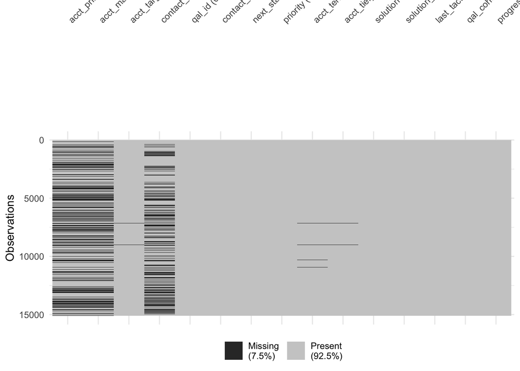

```r
vis_miss(qal_model)
```

# 4 Overall Product Performance

```r
qal_model |>
  group_by(solution_rollup) |>
  summarise(
    leads = n(),
    progression_rate = mean(progressed),
    .groups = "drop"
  )
```

```
# A tibble: 3 × 3
  solution_rollup leads progression_rate
  <chr>           <int>            <dbl>
1 Ax                 21            0.381
2 Mx               3827            0.139
3 Qx              11257            0.220
```

Qx materially outperforms Mx in progression rate. This confirms the structural performance gap described in the business context. Given Qx’s maturity and established buyer persona, this difference is not unexpected. The remainder of the analysis focuses on identifying where Mx performs best and why.

# 5 Account Level Analysis

## 5.1 Industry

```r
industry_summary <- qal_model |>
  group_by(acct_target_industry, solution_rollup) |>
  summarise(
    n = n(),
    progression_rate = mean(progressed),
    .groups = "drop"
  )

industry_summary
```

```
# A tibble: 16 × 4
   acct_target_industry solution_rollup     n progression_rate
   <chr>                <chr>           <int>            <dbl>
 1 Blood & Biologics    Ax                  1           0
 2 Blood & Biologics    Mx                 95           0.189
 3 Blood & Biologics    Qx                324           0.281
 4 Medical Device       Ax                  5           0.4
 5 Medical Device       Mx                886           0.167
 6 Medical Device       Qx               2628           0.246
 7 Non-Life Science     Ax                  9           0.333
 8 Non-Life Science     Mx                944           0.124
 9 Non-Life Science     Qx               4203           0.190
10 Pharma & BioTech     Ax                  6           0.5
11 Pharma & BioTech     Mx               1842           0.132
12 Pharma & BioTech     Qx               3970           0.231
13 Unknown              Mx                 51           0.0392
14 Unknown              Qx                 99           0.0404
15 <NA>                 Mx                  9           0.444
16 <NA>                 Qx                 33           0.455
```

Industry-level differences suggest that Mx performs more strongly within manufacturing-heavy life sciences segments and more weakly in service-oriented or non-manufacturing organizations. This aligns with expectations that Mx requires operational production environments to demonstrate value.

## 5.2 Manufacturing Model

```r
manufacturing_summary <- qal_model |>
  group_by(acct_manufacturing_model, solution_rollup) |>
  summarise(
    n = n(),
    progression_rate = mean(progressed),
    .groups = "drop"
  )

manufacturing_summary
```

```
# A tibble: 46 × 4
   acct_manufacturing_model solution_rollup     n progression_rate
   <chr>                    <chr>           <int>            <dbl>
 1 503A                     Mx                 10            0.6
 2 503A                     Qx                 12            0.417
 3 503B                     Mx                 18            0.278
 4 503B                     Qx                 31            0.548
 5 CDMO                     Mx                410            0.180
 6 CDMO                     Qx                517            0.265
 7 CMO                      Ax                  2            0.5
 8 CMO                      Mx                244            0.254
 9 CMO                      Qx                455            0.371
10 CPO                      Mx                 14            0.143
# ℹ 36 more rows
```

Manufacturing-aligned organizations (In-House, CDMO, CMO) tend to show higher Mx progression rates than non-manufacturing firms. This suggests that Mx has a more narrowly defined ideal customer profile (ICP) centered on operational manufacturers.

## 5.3 Company Size

```r
size_summary <- qal_model |>
  group_by(acct_tier_rollup, solution_rollup) |>
  summarise(
    n = n(),
    progression_rate = mean(progressed),
    .groups = "drop"
  )

size_summary
```

```
# A tibble: 13 × 4
   acct_tier_rollup solution_rollup     n progression_rate
   <chr>            <chr>           <int>            <dbl>
 1 Large            Ax                  3           0
 2 Large            Mx                563           0.0799
 3 Large            Qx               1396           0.138
 4 Medium           Ax                 10           0.4
 5 Medium           Mx               2376           0.138
 6 Medium           Qx               6521           0.229
 7 Other            Mx                 57           0.0526
 8 Other            Qx                124           0.0323
 9 Small            Ax                  8           0.5
10 Small            Mx                822           0.185
11 Small            Qx               3183           0.242
12 <NA>             Mx                  9           0.444
13 <NA>             Qx                 33           0.455
```

# 6 Title-Level Feature Engineering

```r
qal_model <- qal_model |>
  mutate(
    title_lower = tolower(contact_lead_title),
    seniority = case_when(
      str_detect(title_lower, "chief|ceo|cfo|coo|cio|cto") ~ "C-Level",
      str_detect(title_lower, "vp|vice") ~ "VP",
      str_detect(title_lower, "director") ~ "Director",
      str_detect(title_lower, "manager") ~ "Manager",
      is.na(title_lower) ~ "Missing",
      TRUE ~ "Other"
    ),
    has_quality = str_detect(title_lower, "quality"),
    has_ops = str_detect(title_lower, "operat|manufactur|engineer"),
    has_reg = str_detect(title_lower, "regulat")
  )
```

Title engineering introduces structured signals for seniority and function. These variables are expected to be among the strongest predictors in downstream modeling.

## 6.1 Seniority

```r
seniority_summary <- qal_model |>
  group_by(seniority, solution_rollup) |>
  summarise(
    n = n(),
    progression_rate = mean(progressed),
    .groups = "drop"
  )

seniority_summary
```

```
# A tibble: 15 × 4
   seniority solution_rollup     n progression_rate
   <chr>     <chr>           <int>            <dbl>
 1 C-Level   Ax                  1            0
 2 C-Level   Mx                712            0.142
 3 C-Level   Qx               1465            0.259
 4 Manager   Ax                  5            0.4
 5 Manager   Mx                783            0.153
 6 Manager   Qx               2113            0.293
 7 Missing   Ax                  9            0.333
 8 Missing   Mx                964            0.107
 9 Missing   Qx               4299            0.151
10 Other     Ax                  4            0.5
11 Other     Mx               1169            0.154
12 Other     Qx               3010            0.243
13 VP        Ax                  2            0.5
14 VP        Mx                199            0.146
15 VP        Qx                370            0.254
```

## 6.2 Functional Alignment

```r
function_summary <- qal_model |>
  group_by(has_ops, has_quality, solution_rollup) |>
  summarise(
    n = n(),
    progression_rate = mean(progressed),
    .groups = "drop"
  )

function_summary
```

```
# A tibble: 14 × 5
   has_ops has_quality solution_rollup     n progression_rate
   <lgl>   <lgl>       <chr>           <int>            <dbl>
 1 FALSE   FALSE       Ax                  7            0.286
 2 FALSE   FALSE       Mx               1469            0.152
 3 FALSE   FALSE       Qx               3664            0.245
 4 FALSE   TRUE        Ax                  2            0.5
 5 FALSE   TRUE        Mx                477            0.193
 6 FALSE   TRUE        Qx               2120            0.287
 7 TRUE    FALSE       Ax                  3            0.667
 8 TRUE    FALSE       Mx                837            0.122
 9 TRUE    FALSE       Qx                878            0.272
10 TRUE    TRUE        Mx                 80            0.15
11 TRUE    TRUE        Qx                296            0.267
12 NA      NA          Ax                  9            0.333
13 NA      NA          Mx                964            0.107
14 NA      NA          Qx               4299            0.151
```

# 7 Combined Account & Title Patterns

```r
combined_summary <- qal_model |>
  group_by(acct_manufacturing_model, seniority, solution_rollup) |>
  summarise(
    n = n(),
    progression_rate = mean(progressed),
    .groups = "drop"
  ) |>
  arrange(desc(progression_rate))

combined_summary
```

```
# A tibble: 196 × 5
   acct_manufacturing_model     seniority solution_rollup     n progression_rate
   <chr>                        <chr>     <chr>           <int>            <dbl>
 1 503B                         VP        Qx                  2                1
 2 CPO                          C-Level   Qx                  6                1
 3 CPO                          Missing   Mx                  1                1
 4 In-House                     VP        Ax                  1                1
 5 Not Enough Info Found        Manager   Ax                  1                1
 6 Original Equipment Manufact… VP        Mx                  1                1
 7 Research Institute           VP        Qx                  3                1
 8 Services / Consulting        Missing   Ax                  1                1
 9 Services / Consulting        Other     Ax                  1                1
10 Testing Laboratory           VP        Qx                  5                1
# ℹ 186 more rows
```

# 8 Lead Source Analysis

```r
channel_summary <- qal_model |>
  group_by(last_tactic_campaign_channel, solution_rollup) |>
  summarise(
    n = n(),
    progression_rate = mean(progressed),
    .groups = "drop"
  )

channel_summary
```

```
# A tibble: 26 × 4
   last_tactic_campaign_channel solution_rollup     n progression_rate
   <chr>                        <chr>           <int>            <dbl>
 1 Direct/Inbound               Ax                 13           0.308
 2 Direct/Inbound               Mx                272           0.298
 3 Direct/Inbound               Qx               1126           0.353
 4 Directory Listing            Mx                 94           0.213
 5 Directory Listing            Qx                847           0.223
 6 Email                        Ax                  2           0.5
 7 Email                        Mx               1084           0.0637
 8 Email                        Qx               2500           0.0564
 9 Events                       Mx                183           0.224
10 Events                       Qx                160           0.206
# ℹ 16 more rows
```

# 9 Modeling Implications

This exploratory analysis suggests that predictive modeling should incorporate:

- Product family
- Industry
- Manufacturing model
- Company tier
- Seniority
- Functional title signals
- Missingness indicators
- Interaction terms (product × title, product × manufacturing)

# 10 Conclusion

This EDA confirms that:

A predictive model incorporating engineered title signals and account attributes has strong potential to improve:

- Sales prioritization
- ICP refinement
- Go-to-market efficiency
- Pipeline conversion rates

# 11 Group Member Contributions

- **Miles** — Target construction, missingness analysis, feature engineering (title signals), modeling framing, interaction insights
- **Sebastian** — Account-level segmentation analysis, progression tables, business interpretation
- **Jeffrey** — Channel analysis, visualization development, product comparison summaries